# Chapter 9 Homework

### Congressional Text Data

For this problem set, we will look at data from congressional speeches. This data first appear in Gentzkow and Shapiro (2010) an summarize the first year of the 109th Congressional Record (2005) containing all speech in that year for members of the US house and senate.

The text is already tokenized into bigrams (two-word prhases) after stop-word removal and stemming (using a Porter stemmer). The matrix congress109Counts contains the number of times each phrase in a list of 1000 common bigram and trigrams was used in the 109th Congress by each of the 529 members of the House and Senate.

```r
library(textir)
data(congress109)
congress109Counts[c("Barack Obama", "John Boehner"), 995:998]
```

```
2 x 4 sparse Matrix of class "dgCMatrix"
             stem.cel natural.ga hurricane.katrina trade.agreement
Barack Obama        .          1                20               7
John Boehner        .          .                14               .
```

The data also contain information about each member of Congress.

```r
congress109Ideology[1:4,]
```

|  | name | party | state | chamber | repshare | cs1 | cs2 |
| --- | --- | --- | --- | --- | --- | --- | --- |
| Chris Cannon | Chris Cannon | R | UT | H | 0.7900621 | 0.534 | -0.124 |
| Michael Conaway | Michael Conaway | R | TX | H | 0.7836028 | 0.484 | 0.051 |
| Spencer Bachus | Spencer Bachus | R | AL | H | 0.7812933 | 0.369 | -0.013 |
| Mac Thornberry | Mac Thornberry | R | TX | H | 0.7776520 | 0.493 | 0.002 |

We will be considering the variable `repshare` which is the proportion of the two party vote by the members constituents (districts for members of the house, state for senators) that was captured by the republican candidate (GW Bush) in the 2004 presidential election.

**Fit a lasso regression that predicts `repshare` from whether or not each member used each text token. What are the most republican and most democratic tokens?**

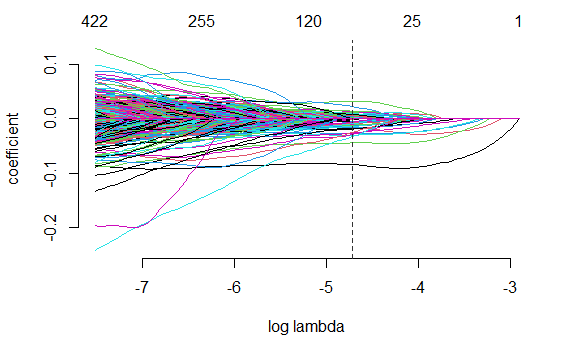

```r
x <- congress109Counts>0
y <- congress109Ideology$repshare
fitlin <- gamlr(x, y)
plot(fitlin)
```

```r
# use the AICc coefficients
b <- coef(fitlin)[-1,]
# Democrat words (most negative loading to predict repshare)
sort(b)[1:10]
```

```
   congressional.black.caucu                 family.value
                 -0.08387560                  -0.04426433
       issue.facing.american           voter.registration
                 -0.03238695                  -0.02980049
     minority.owned.business            strong.opposition
                 -0.02836725                  -0.02641424
                 civil.right        universal.health.care
                 -0.02592469                  -0.02535887
congressional.hispanic.caucu          ohio.electoral.vote
                 -0.01871743                  -0.01825136
```

```r
# Republican words
sort(b, decreasing=TRUE)[1:10]
```

```
million.illegal.alien          human.embryo        action.lawsuit
          0.032834770           0.022649374           0.014197349
     private.property            war.terror          look.forward
          0.013328544           0.011421180           0.009855941
           global.war   illegal.immigration        percent.growth
          0.009842767           0.008716802           0.008305923
        illegal.alien
          0.007919288
```

**Fit a 10 topic LDA model. Can you identify any of the topics as being related to specific subjects or political beliefs?**

```r
library(text2vec)
tpc <- LDA$new(n_topics=10)
W <- tpc$fit_transform(x)
```

Looking at topic token probabilities we can see some broad themes (civil rights, environmentalism, job creation, spending).

```r
tpc$get_top_words(n=5, lambda=1)
```

```
     [,1]             [,2]                  [,3]
[1,] "food.stamp"     "war.iraq"            "civil.right"
[2,] "student.loan"   "veteran.health.care" "low.income"
[3,] "billion.tax"    "party.line"          "education.program"
[4,] "budget.deficit" "american.value"      "right.movement"
[5,] "child.support"  "military.famili"     "rosa.park"
     [,4]                  [,5]                [,6]
[1,] "american.people"     "trade.agreement"   "create.job"
[2,] "democrat.republican" "gulf.coast"        "tax.rate"
[3,] "strong.support"      "appropriation.bil" "ronald.reagan"
[4,] "war.terror"          "fre.trade"         "tax.increase"
[5,] "national.guard"      "central.american"  "saddam.hussein"
     [,7]                    [,8]
[1,] "national.debt"         "american.people"
[2,] "security.trust.fund"   "strong.support"
[3,] "security.trust"        "million.american"
[4,] "social.security.trust" "stem.cel"
[5,] "cut.medicaid"          "cel.research"
     [,9]                     [,10]
[1,] "natural.ga"             "court.appeal"
[2,] "foreign.oil"            "circuit.court"
[3,] "dependence.foreign.oil" "chief.justice"
[4,] "national.wildlife"      "court.judge"
[5,] "wildlife.refuge"        "foreign.relation"
```

The story out of topic token lifts is a bit different, and we see more specific issues referenced in the top of each topic.

```r
tpc$get_top_words(n=5, lambda=0)
```

```
     [,1]                  [,2]
[1,] "fund.tax.cut"        "national.endowment.humaniti"
[2,] "tax.break.oil"       "plan.bring.troop"
[3,] "able.buy.gun"        "health.care.cut"
[4,] "warren.buffett"      "gun.lobby"
[5,] "victim.gun.violence" "supreme.court.rejected"
     [,3]                         [,4]
[1,] "national.heritage.corridor" "driver.education"
[2,] "ready.mixed.concrete"       "improvised.explosive.device"
[3,] "ohio.electoral.vote"        "dr.martin.luther"
[4,] "western.energy.crisi"       "camp.pendleton"
[5,] "city.san.francisco"         "million.budget.request"
     [,5]                   [,6]
[1,] "indian.art.craft"     "plan.reform"
[2,] "economic.growth.job"  "million.job.created"
[3,] "duty.fre"             "reform.social.security"
[4,] "trial.lawyer"         "near.retirement.age"
[5,] "american.farm.bureau" "nation.oil.food"
     [,7]                     [,8]
[1,] "regional.training.cent" "using.adult.stem"
[2,] "united.airline.employe" "winning.war.iraq"
[3,] "deep.sea.coral"         "arab.oil.embargo"
[4,] "national.ad.campaign"   "embryo.stem.cel"
[5,] "children.live.poverty"  "type.stem.cel"
     [,9]                       [,10]
[1,] "low.cost.reliable"        "gifted.talented.student"
[2,] "kaiser.family.foundation" "arm.embargo.china"
[3,] "mount.st.helen"           "marriage.protection.amendment"
[4,] "fuel.efficiency.standard" "ga.price.reduction"
[5,] "rising.ga.price"          "summa.cum.laude"
```

**Regress repshare onto the 10 topic LDA. What does this tell you about the partisanship of these topics?**

```r
fitLDA <- glm(y ~ W)
summary(fitLDA)
```

```
Call:
glm(formula = y ~ W)

Deviance Residuals:
     Min        1Q    Median        3Q       Max
-0.45079  -0.05377   0.00501   0.06607   0.32761

Coefficients: (1 not defined because of singularities)
            Estimate Std. Error t value Pr(>|t|)
(Intercept)  0.69636    0.04169  16.702  < 2e-16 ***
W1          -0.25438    0.07230  -3.518 0.000473 ***
W2          -0.43936    0.08528  -5.152 3.67e-07 ***
W3          -0.55979    0.05925  -9.448  < 2e-16 ***
W4          -0.03721    0.07043  -0.528 0.597458
W5           0.06764    0.07263   0.931 0.352134
W6           0.04026    0.06359   0.633 0.526908
W7          -0.41497    0.07508  -5.527 5.17e-08 ***
W8          -0.13550    0.05898  -2.298 0.021987 *
W9          -0.24788    0.07241  -3.423 0.000668 ***
W10               NA         NA      NA       NA
---
Signif. codes:  0 ‘***’ 0.001 ‘**’ 0.01 ‘*’ 0.05 ‘.’ 0.1 ‘ ’ 1

(Dispersion parameter for gaussian family taken to be 0.0114408)

    Null deviance: 9.6485  on 528  degrees of freedom
Residual deviance: 5.9378  on 519  degrees of freedom
AIC: -851.79

Number of Fisher Scoring iterations: 2
```